# Poisson regression theory

Michael R. McLaren

Adam Howes

- https://web.stanford.edu/class/archive/stats/stats200/stats200.1172/Lecture27.pdf
- https://www.utstat.toronto.edu/~brunner/oldclass/2201s11/readings/glmbook.pdf

## Background

The Poisson regression model is of the form
$$y_i \sim \text{Poisson}(\lambda_i), \\
\log(\lambda_i) = \beta^\top x_i,$$
where $\beta = (\beta_1, \ldots, \beta_p)$. In a frequentist setting, the likelihood is
$$\mathcal{L}(\beta) = \prod_{i = 1}^n
\frac{\exp{(-\lambda_i)}\lambda_i^{y_i}}{y_i!} \propto \prod_{i = 1}^n
\exp{(-\lambda_i)}\lambda_i^{y_i}$$

with corresponding log-likelihood (up to a constant)
$$\ell(\beta) = \sum_{i = 1}^n -\lambda_i + y_i \log(\lambda_i) \\
= \sum_{i = 1}^n y_i (\beta^\top x_i) -\exp(\beta^\top x_i)$$
The partial derivative of the log likelihood with respect to the $j$th entry of $\beta$ is
$$\frac{\delta \ell(\beta)}{\partial \beta_j} = \sum_{i = 1}^n x_{ij}(y_i
- \exp(\beta^\top x_i)),$$
and the second partial derivative is
$$\frac{\delta^2 \ell(\beta)}{\partial \beta_j \partial \beta_k} = \sum_{i
= 1}^n - x_{ij} \exp(\beta^\top x_i)) x_{ik}.$$

Let $W = W(\beta)$ be the diagonal matrix $\text{diag}(\exp(\beta^\top x_1), \ldots, \exp(\beta^\top x_n))$, and $X_j = (x_{1j}, \ldots, x_{nj})$ be the $j$th column of the covariate matrix $X$. Then the second partial derivative may be rewritten as $- X_j^\top W X_k$ such that $\nabla^2 \ell(\beta) = - X^\top W X$ and $\mathcal{I}(\beta) = X^\top W X$.

For large $n$, the maximum likelihood estimator $\hat \beta \sim \mathcal{N}(\beta, (X^\top W X)^{-1})$ such that the standard error of $\beta_j$ is approximately
$$\sqrt{(X^\top \hat W X)^{-1}_{jj}}$$

### Time as a covariate

Suppose that we have one covariate, the time $t_i$ at which the measurement was taken, together with an intercept
$$\log(\lambda_i) = \beta^\top x_i = \beta_0 + \beta t_i.$$
Let $\hat \lambda_i = \exp(\hat \beta_0 + \hat \beta t_i)$ be the fitted values, then the matrix $\hat W$ is
$$\hat W = \text{diag}(\hat \lambda_1, \ldots, \hat \lambda_n)$$
and the columns of the covariate matrix are $X_1 = (1, \ldots, 1)$ and $X_2 = (t_1, \ldots, t_n)$. The estimated Fisher information matrix is
$$\hat{\mathcal{I}} =
\begin{pmatrix}
\sum_{i = 1}^n \hat \lambda_i & \sum_{i = 1}^n t_i \hat \lambda_i \\
\sum_{i = 1}^n t_i \hat \lambda_i & \sum_{i = 1}^n t_i^2 \hat
\lambda_i
\end{pmatrix}$$
with inverse
$$\hat{\mathcal{I}}^{-1} =
\frac{1}{\sum_{i = 1}^n \hat \lambda_i \sum_{i = 1}^n t_i^2 \hat
\lambda_i - (\sum_{i = 1}^n t_i \hat \lambda_i)^2}
\begin{pmatrix}
\sum_{i = 1}^n t_i^2 \hat \lambda_i & -\sum_{i = 1}^n t_i \hat
\lambda_i \\
-\sum_{i = 1}^n t_i \hat \lambda_i & \sum_{i = 1}^n \hat \lambda_i
\end{pmatrix}$$

Let’s test this with some R code:

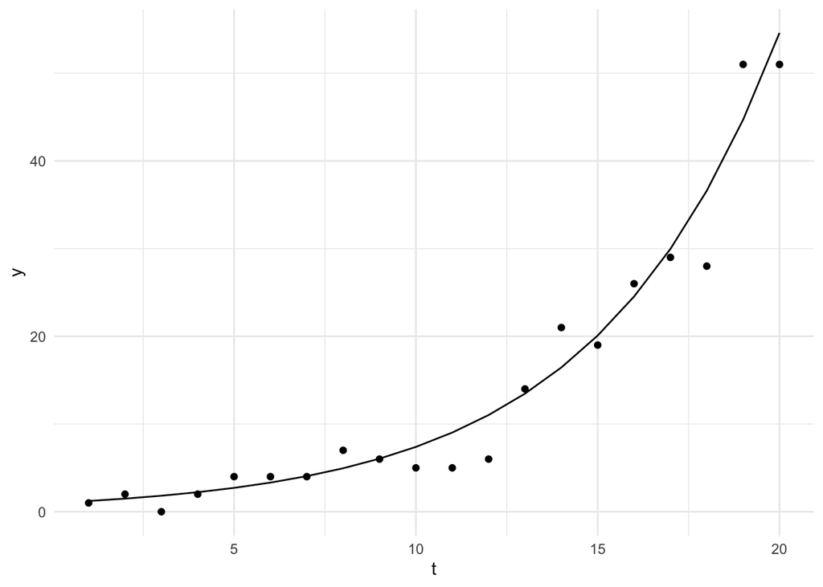

```r
library(tidyverse, quietly = TRUE)

n <- 20
t <- 1:n
beta <- 0.2
beta0 <- 0
lambda <- exp(beta0 + beta * t)
y <- rpois(n, lambda)

sim <- tibble(t = 1:n) %>%
  mutate(
    beta0 = 0,
    beta = 0.2,
    lambda = exp(beta0 + beta * t),
    y = rpois(n(), lambda)
  )

ggplot(sim, aes(x = t, y = y)) +
  geom_point() +
  geom_line(aes(y = lambda)) +
  theme_minimal()
```

```r
fit <- glm(y ~ t, family = poisson, data = sim)
coef <- broom::tidy(fit, conf.int = TRUE)

lambda_hat <- fit$fitted.values

X <- matrix(c(rep(1, n), t), ncol = 2)
I_hat <- t(X) %*% diag(lambda_hat) %*% X
I_hat
```

```
##      [,1]     [,2]
## [1,]  285  4535.00
## [2,] 4535 77011.94
```

```r
I_hat_11 <- sum(lambda_hat)
I_hat_12 <- sum(t * lambda_hat)
I_hat_22 <- sum(t^2 * lambda_hat)

I_hat_manual <- matrix(c(I_hat_11, I_hat_12, I_hat_12, I_hat_22), ncol = 2)
I_hat_manual
```

```
##      [,1]     [,2]
## [1,]  285  4535.00
## [2,] 4535 77011.94
```

```r
I_hat_inv <- solve(I_hat)
I_hat_inv
```

```
##              [,1]          [,2]
## [1,]  0.055717826 -0.0032810541
## [2,] -0.003281054  0.0002061963
```

```r
I_hat_inv_manual <- 1 / (I_hat_11 * I_hat_22 - (I_hat_12^2)) * matrix(c(I_hat_22, -I_hat_12, -I_hat_12, I_hat_11), ncol = 2)
I_hat_inv_manual
```

```
##              [,1]          [,2]
## [1,]  0.055717826 -0.0032810541
## [2,] -0.003281054  0.0002061963
```

```r
sqrt(c(I_hat_inv[1, 1], I_hat_inv[2, 2]))
```

```
## [1] 0.23604624 0.01435954
```

```r
coef$std.error
```

```
## [1] 0.23604565 0.01435951
```

This all matches up.

Here is an attempt at a fitted 95% confidence interval (for the mean) based on [this](https://fromthebottomoftheheap.net/2018/12/10/confidence-intervals-for-glms/).

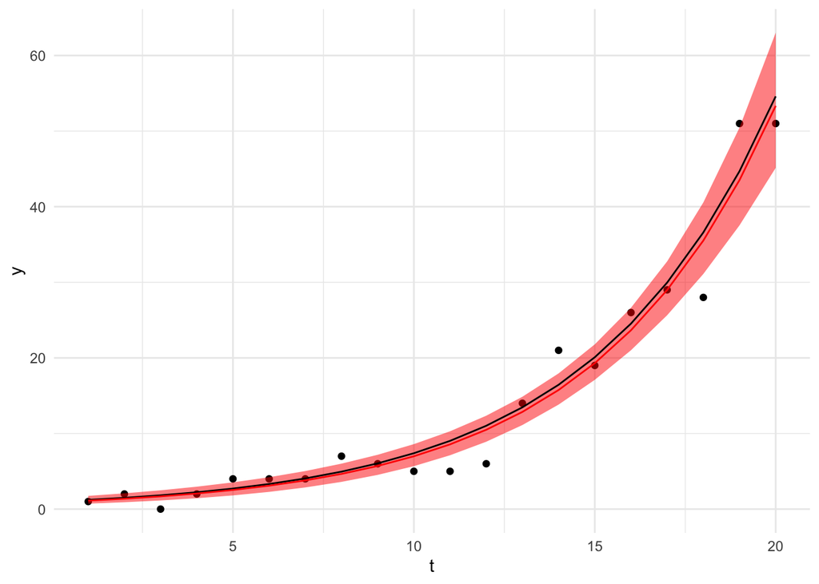

```r
ci <- predict(fit, newdata = data.frame(t = 1:20), se.fit = TRUE, type = "link")
upr_latent <- ci$fit + 2 * ci$se.fit
lwr_latent <- ci$fit - 2 * ci$se.fit
upr <- fit$family$linkinv(upr_latent) #' This is just exp()
lwr <- fit$family$linkinv(lwr_latent)

sim$upr <- upr
sim$pred <- fit$family$linkinv(ci$fit)
sim$lwr <- lwr

ggplot(sim, aes(x = t, y = y, ymax = upr, ymin = lwr)) +
  geom_point() +
  geom_ribbon(alpha = 0.5, fill = "red") +
  geom_line(aes(y = lambda)) +
  geom_line(aes(y = pred), col = "red") +
  theme_minimal()
```